# Assignment 3

Steven Hizmi

#### Due Friday, September 18 at 11:59 PM CT

### Problems

Choose to do either the set of three problems 1A, 2A, and 3A with the US Death data or the three problems 1B, 2B, 3B with the S&P 500 data.

### 1A

Based on death counts and population and demographic data, a department within the US Center for Disease Control (CDC) makes a prediction interval for what the total number of US deaths is expected to be. This interval accounts for changes in the population, the age structure, and several other demographic variables. The prediction interval accounts for variation at typical levels judged over many years. When the actual death count exceeds the maximum of the prediction interval for several consecutive weeks, this is evidence that there is some cause of excess deaths.

The following code is a simple line plot of the actual deaths and the maximum number of predicted deaths under normal conditions since January, 2017. Note that the command `scale_x_date()` is useful to have more control over the labeling of dates on the x-axis. Here, the pattern “%b-%Y” specifies pattern with an abbreviation for the month, a dash, and the four-digit year. See the help page by typing `?scale_x_date` for more details.

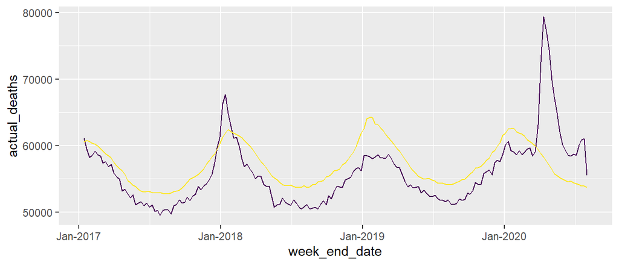

> What do you thing explains the cyclical pattern in the line plot of the upper end of the prediction interval? How does the death rate tend to change with season?

It seems as if the death rate increases faster during the winter months. It could be likely that the cold weather and death rate are positively correlated. It seems that the death rate is highest in winter and lowest in summer.

### 2A

Make changes to the code so that:

- The value zero appears on the y-axis so we can better compare relative rates.
- The values on the y-axis are divided by 10,000
- There are clear and informative axis labels and a title.

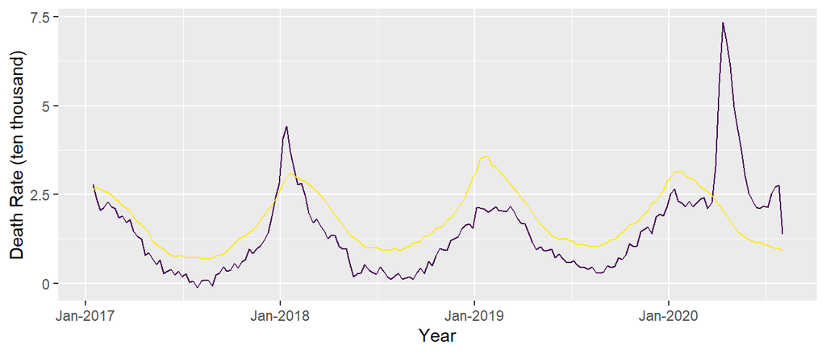

> When are the two time periods when the number of actual death greatly exceeds the maximum expected number of deaths over several consecutive weeks?

January of 2018 and around March-April of 2020

### 3A

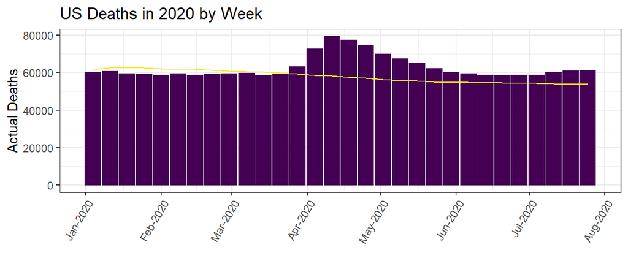

> When during the year did the number of actual deaths begin to greatly exceed the maximum expected number? When did the number of excess deaths peak? Is the current trend of excess deaths increasing or decreasing?

Around April the actual deaths began to greatly exceed the maximum expected number. The deaths seemed to peak mid April. The current trend seems to be increasing slightly but not by much.

### 1B

The following code is a simple line plot of the S&P 500 Index closing value and the daily high.

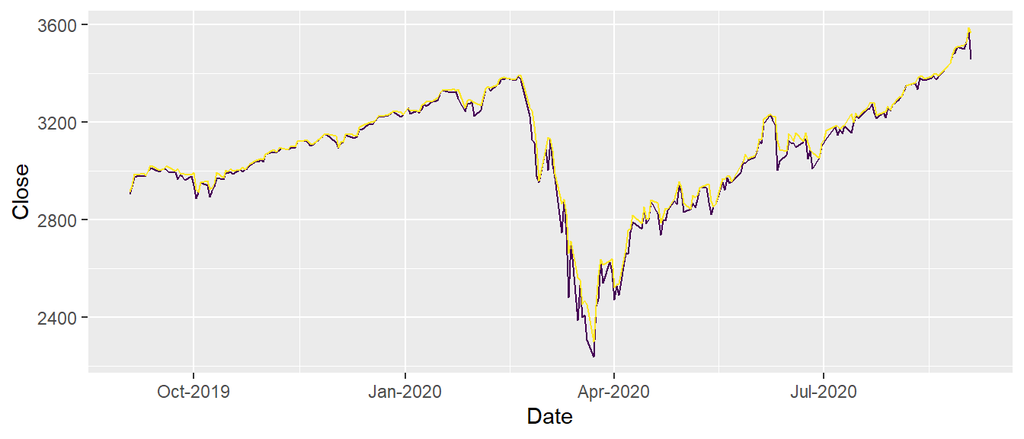

> Provide a description of the pattern you see.

### 2B

Make changes to the code so that:

- The value 0 appears on the y-axis.
- There are clear and informative axis labels and a title.
- Change the colors of the lines to something different.

[figure not shown]

About what percentage of the value of S&P dropped from its peak in mid March to the lowest point in late March?

### 3B

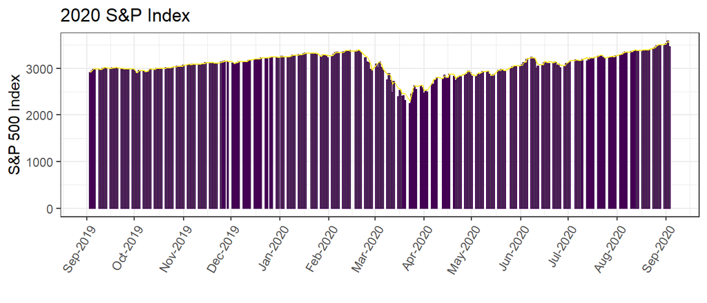

Make the plot as above and again with the `scale_x_date()` line commented out.

> What do you think this line of code does?

> Repeat for the last line of code with `theme(...)`

### 4

> Explain the difference between the `geom_col()` and `geom_bar()` functions.

geom_col() leaves the data alone and represents it as is. geom_bar() makes the height of the bar proportional to the amount of data it has for the corresponding bar.

### 5

The following block of code make two different scatter plots of mass on a log scale versus year.

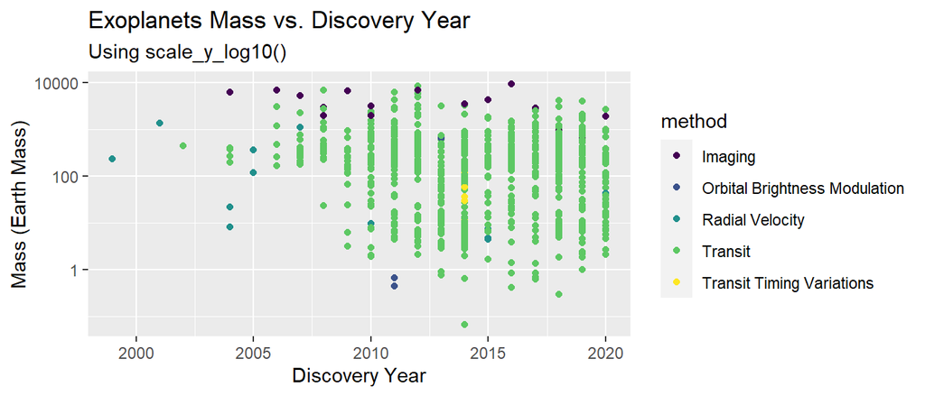

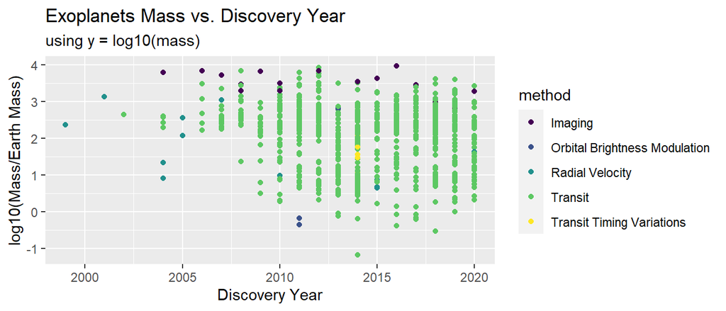

> Describe the differences between the two plots. Which do you think is more effective and why?

### 6

Using the exoplanet data, make a plot with discovery year on the x axis, mass on the log10 scale on the y-axis, and with a different facet for each method. Set the argument `position` within the `geom_point()` command using the command `position_jitter()` so that points are jittered horizontally, but not vertically. Choose an amount of jitter so that there is a reduction in overplotting, but all points for a single year appear as a band without overlap with other years.

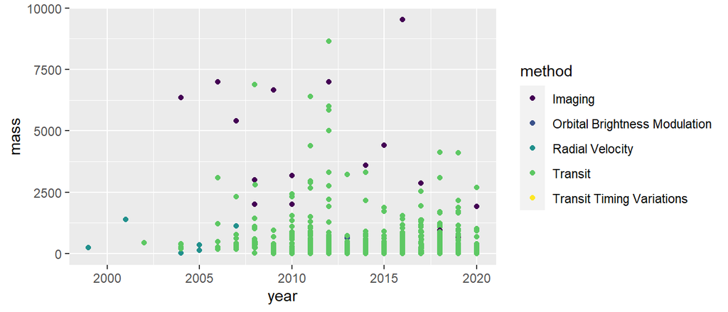

```r
ggplot(planets, aes(x = year, y = mass, color = method)) +
  geom_point(position = position_jitter(width=0.0025, height=0.0025))
```

### 7

With the exoplanet data, make a bar graph of the method variable that displays the count of the number of observations for each method.

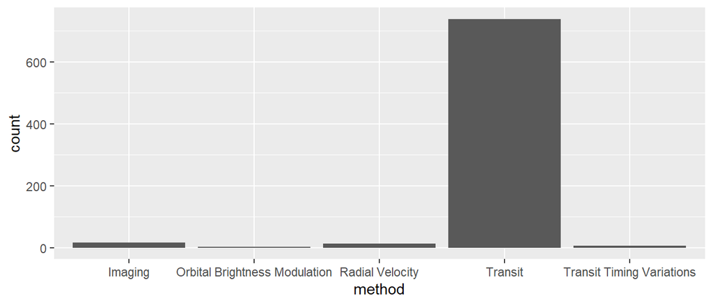

```r
ggplot(planets, aes(method)) +
  geom_bar()
```

### 8

Repeat the previous problem, but replace the counts on the y-axis with proportions. (*Hint:* You need to set the `y` aesthetic to `stat(prop)` and the group aesthetic to `1`. See the second example in *R for Data Science* section 3.7.)

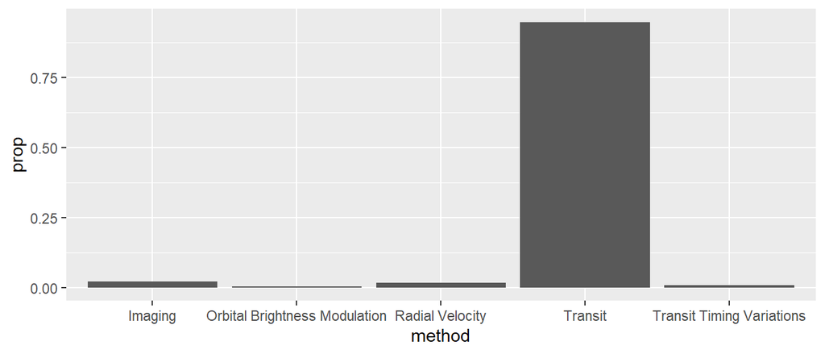

```r
ggplot(planets, aes(method)) +
  geom_bar(aes(y = stat(prop), group = 1))
```

### 9

#### (a)

> What does the line `select(-days)` do to the data set?

#### (b)

> What does the command `drop_na()` do? How many rows (observations) are in the data set when it is first read in and how many rows remain after this code is executed?

drops rows that contain missing data. 175 rows before, and 172 rows after the drop_na() command.

#### (c)

> Describe the effect these three lines of code have on the data set

separate returns an input of a single character column into multiple character column. In this case it seems to separate winter into 2 different years, most likely because of the New Year. first mutate: forces year1 column to be numbers instead of whatever type is there before second mutate: makes year2 column same as year1 column but adds 1 to it.

#### (d)

> Explain what the effect of these two commands are. In your response, describe what the effect of the `group_by(winter)` command is, what the function `n()` does, and what the functions `sum()`, `min()`, and `max()` do.

group_by(winter) groups all the days and their data that occurred in winter, so you can compare the winter days easier. intervals = n() means that the rows are assigned to the variable intervals. sum() adds all elements in the data structure together to produce a sum. min() finds the lowest value element in the parameter. max() finds the highest value element in the parameter.